# Fast and reliable use of numerical solvers

Juho Timonen and Ben Bales

2020-10-26

```r
# Requirements
require(rstan)
library(tidyverse)
require(bayesplot)
require(ggplot2)
require(loo)
require(stats)
require(posterior)
set.seed(123) # rng seed for data simulation
```

The required `posterior` package is not in CRAN but can be installed via `install.packages("posterior", repos = c("https://mc-stan.org/r-packages/", getOption("repos")))`.

# 1 Introduction

Assume we have a Bayesian model that involves an ODE or PDE (ordinary or partial differential equation) system with uncertain parameters. When performing Bayesian inference for these parameters (and possible other model parameters) using Stan, the system needs to be solved numerically on each log posterior probability evaluation. Furthermore, Stan needs to compute gradients for these solutions. Try as we might, these computations are often expensive and frequently become the limiting factors in whatever model they are involved in.

The numerical methods for ODEs and PDEs usually involve some discretization in space/time, which affects the solver accuracy. Denser discretization means more accuracy but also more computation. Alternatively, methods can estimate their error and adapt their step size so that a given tolerance is achieved. The latter is what the built-in ODE solvers in Stan do.

The simplest things we might do to speed up our calculations are lowering the timestep, coarsening the discretization, or increasing the tolerance of the solvers. That immediately leaves us with the question, is this okay? Has changing the numerical method affected our parameter inference results? Was our original method giving correct inference results to begin with? Are the default tolerances in Stan suitable for the problem at hand?

The solution provided by a numerical method is always an approximation to the true solution, which is general does not have a closed form. This is why our posterior probability density evaluations are also approximations and the whole MCMC inference can be thought to be biased to some degree. However, we can think that the inference results are correct if making the numerical method more accurate does not affect the statistical properties of the posterior draws.

How can something like this be checked? The first problem is that it might not be computationally very attractive to run sampling repeatedly, gradually increasing the solver accuracy. If the model parameters are fixed, we can verify that the solution at all points in space/time is appropriately close to a more accurate reference solution. That isn’t so much of a problem in and of itself, but we’re doing statistics, and so we need to know that the solution is accurate enough across all relevant parts of parameter space. Additionally, it is not known beforehand where the “relevant parts of parameter space” are!

The problem of validating the use of a numerical method for a Bayesian model is therefore significantly more complicated than in the classical numerical analysis world. The point of this case study is to show how by adding one additional tool, namely Pareto-Smoothed Importance Sampling (PSIS) (Yao et al. 2018; Vehtari et al. 2019), we can solve this problem.

# 2 Workflow

Let $M$ be the model for which we would like to perform inference, but which we cannot evaluate since the likelihood is defined implicitly through an ODE or PDE system that is not analytically tractable. MCMC inference for $M$ can be seen actually as inference for another model $M_{high}$, which is the same model as $M$ but using a numerical solver, and can therefore be evaluated.

Our workflow addresses the problem of defining the high-precision numerical method in $M_{high}$ so that $M_{high}$ can trusted to have essentially the same posterior as $M$. We define a way to perform inference for $M_{high}$ without needing to compute gradients or HMC trajectories for it. This involves another model $M_{low}$, which is again the same model, except that $M_{low}$ uses a cheaper and less accurate numerical methods (or just looser tolerances and/or coarser discretization) to compute the required ODE or PDE solutions, and is therefore faster to fit. The posterior densities are denoted $p_{low}$ and $p_{high}$, respectively.

To understand how PSIS comes into play, we must first discuss importance sampling. If we want to compute expectations with the high precision model, we can take draws from the low precision models and reweight these according to the importance weights $\frac{p_{high}}{p_{low}}$. If these models are too different, then the reweighting will produce noisy estimates that are not useful. PSIS and particularly the Pareto $k$-diagnostic (denoted $\hat{k}$), is the tool that tells us when we can or cannot rely on the importance weights. If $\hat{k} < 0.5$ we are safe to do the importance sampling, if $\hat{k} < 0.7$ the importance sampling will start to converge more slowly, and if $\hat{k} > 0.7$ the importance sampling estimates are unreliable. For simplicity we will only consider the $\hat{k} < 0.5$ threshold.

Ideally, $M_{high}$ would involve a numerical method that we can trust completely in all parts of the parameter space so that, as long as $\hat{k} < 0.5$, importance weights can be used to reweight the low precision approximation $p_{low}$ to the high precision approximation $p_{high}$. We can think of $M_{high}$ as a reference model, because it is the baseline to which we compare. It is difficult in practice to know if a given model is a good reference model in all parts of parameter space, due to curse of dimensionality and the fact that analysed system can have different properties in different parts of the parameter space. For example, ODEs can qualitatively change their behaviour as a function of parameters (bifurcation), or become stiff or chaotic in some parameter regions. Accuracy can be checked at a given set of parameters fairly easily, but not over a high dimensional parameter space. Under these conditions it is necessary to compromise to develop a reference model that works only over a range of parameter space, but even then it is hard to know *a priori* what range that is.

We propose the following workflow:

1. Generate draws from $p_{low}$.
2. Tune the numerical method in $M_{high}$ so that it is reliable at these draws. All application specific knowledge and classical numerical analysis can be used here.
3. Compute importance weights $\frac{p_{high}}{p_{low}}$
4. Compute the $\hat{k}$ diagnostic. If $\hat{k} > 0.5$, raise precision of the numerical method in $M_{low}$ and go back to step 1.
5. Resample draws of $M_{low}$, using importance weights to get draws from $M_{high}$, and therefore essentially draws from $M$.

The next two sections of this case study outline how to apply this workflow to do fast but reliable inference for

1. an ODE model using a built-in Stan solver
2. a PDE model using a custom solver that does not have explicit tolerance controls

The importance sampling diagnostics are handled with the [`loo`](https://mc-stan.org/loo) package and the resampling is handled with the [`posterior`](https://github.com/stan-dev/posterior) package.

# 3 SIR example (ODE)

Here we study a classic Susceptible-Infected-Recovered (SIR) model of disease spread. The code is adapted from that in the Stan Case Study (Grinsztajn et al. 2020), which provides an introduction to disease transmission modeling in Stan in general.

For the purposes of this case study, the goal is to use a very low precision ODE solver to do inference and then check it afterwards against a high precision solver. This is useful in practice if sampling with the high precision solver itself would take an inordinate amount of time.

The states of the ODE are amounts of susceptible (S), infected (I) and recovered (R) people. The dynamics are given by the ODE system:

$$\begin{align}
\frac{dS}{dt} &= -\beta \cdot I \cdot \frac{S}{N} \\
\frac{dI}{dt} &= \beta \cdot I \cdot \frac{S}{N} - \gamma \cdot I \\
\frac{dR}{dt} &= \gamma \cdot I
\end{align}$$

The parameters $\beta$ and $\gamma$ will be estimated from time series observations of the number of infected people (I).

## 3.1 Solving the system

First, we will import a function from `stan/sir.stan` for solving the ODE. It uses the `integrate_ode_rk45` function that is built into Stan.

```r
model = stan_model("stan/sir.stan")
expose_stan_functions(model)
```

Second, we define various useful constants for our problem (the initial conditions, etc.) and a wrapper function for the Stan function that solves the ODE. The actual function exported from Stan is a bit awkward so we rewrap it here in a way that the only options we will expose are parameters and tolerance arguments.

```r
N = 16                                # number of days measured
M = 1000                              # population size
I0 = 20                               # number of infected on day 0
initial_conditions = c(M - I0, I0, 0) # S, I, R on day 0
ts = seq_len(N)                       # measurement times
theta_true = c(1, 0.2)                # true parameter values

# Solve the SIR system and format result array
# - theta = [beta, gamma]
solve_sir = function(theta, rtol, atol, max_num_steps) {
  stan_solve_sir(initial_conditions, ts, theta,
                 c(0.0), M, rtol, atol, max_num_steps)
}
```

The ODE solvers in Stan are adaptive time step solvers, which estimate the local error of the solution and adapt their step size so that the local error estimates are less than `atol + rtol * abs(y)`, where `y` is the ODE solution, and `atol` and `rtol` are called absolute and relative tolerance, respectively. These tolerances need to be given, and affect both the accuracy and computational cost of the solution. In general, `rtol` is the tolerance on the relative error the solver can make when `y` is far from zero. When `abs(y)` is small (of the order of `atol` or smaller), there is no need to achieve the relative tolerance.

A third control parameter, `max_num_steps`, determines the maximum number of steps that can be taken to achieve the tolerance. In practice, we have observed that setting this to a much smaller value than the default can lower the warmup times of some chains by several orders of magnitude. This can be because it possibly helps in rejecting or quickly getting out of initial low-probability parameter regions, where the ODE solutions blow up and achieving the tolerances would require a much larger number of steps than in the good parameter region.

We can just pick a couple tolerances and quickly run and plot a solution just to get a feel for what the system looks like:

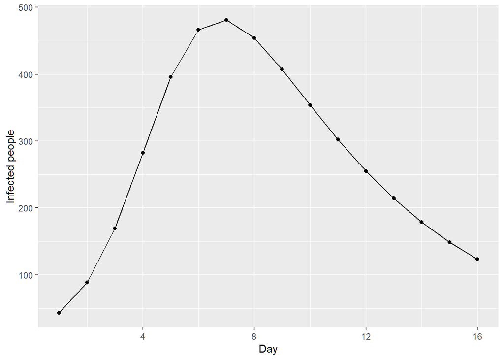

```r
plot_sir = function(y) {
  y %>%
    as_tibble() %>%
    setNames(c("I")) %>%
    mutate(Day = ts) %>%
    ggplot(aes(Day, I)) +
    geom_line() +
    geom_point() +
    ylab("Infected people")
}

plot_sir(solve_sir(theta_true, 1e-4, 1e-4, 100))
```

In this model we are making noisy measurements of the number of infected people (I) at each day.

## 3.2 Generating test data

If we’re going to generate data from our model we better have an accurate ODE solver, otherwise we’re just generating data from some weird approximate model.

The simplest way to check that an `atol` and `rtol` are suitable is to do a solve at one tolerance level, repeat the solve at a much smaller (more precise) tolerance, and then look at the maximum absolute error at any output point. We will create a function to do this automatically:

```r
check_reliability = function(theta, rtol, atol, max_num_steps) {
  y_hat = solve_sir(theta, rtol, atol, max_num_steps)
  y_hat2 = solve_sir(theta, rtol / 10, atol / 10, max_num_steps)
  max_abs_err = max(abs(y_hat - y_hat2))
  return(max_abs_err)
}
```

We can study the maximum absolute error compared to a solution with 10 smaller tolerances, as a function `tol = atol = rtol`.

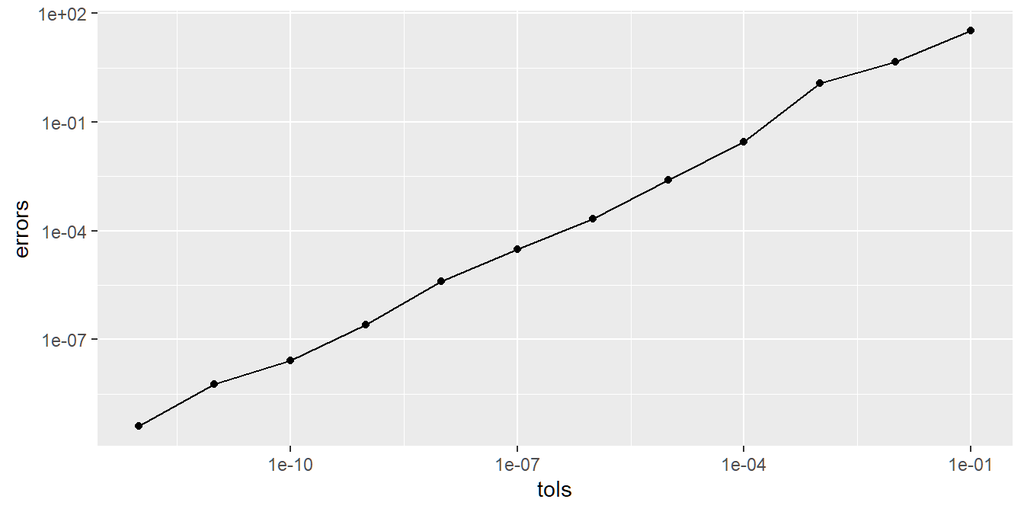

```r
errors = c()
tols = 10^(-c(1:12))
for (tol in tols) {
  errors = c(errors, check_reliability(theta_true, tol, tol, 1e8))
}

qplot(tols, errors, geom = c("point", "line")) +
  scale_x_log10() +
  scale_y_log10()
```

From this and our prior knowledge of infectious diseases, we assert that $10^{-6}$ is a good enough value to use for `atol` and `rtol` during simulation. Certainly we do not expect have a count of the infected population accurate to $10^{-4}$ people.

We assume a negative binomial measurement model to get an observed number of infected people (cases) at each time point.

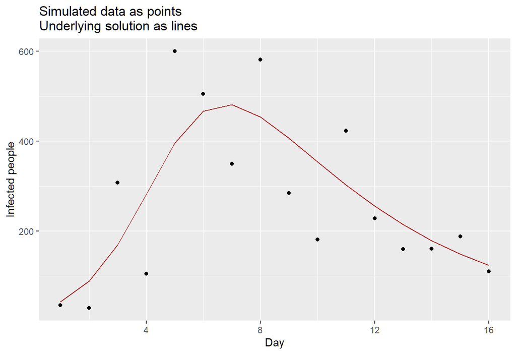

```r
atol =  1e-6
rtol = 1e-6

dispersion = 5 # noise parameter for negative binomial
mu = solve_sir(theta_true, atol, rtol, 1e8)
y = stats::rnbinom(length(ts), mu = mu, size = dispersion)

tibble(t = ts, mu = mu, y = y) %>%
  ggplot() +
  geom_line(aes(t, mu), col = "firebrick") +
  geom_point(aes(t, y)) +
  xlab("Day") +
  ylab("Infected people") +
  ggtitle("Simulated data as points \nUnderlying solution as lines")
```

## 3.3 Applying the workflow

As a reminder, our mission in fitting this ODE is to use a low precision solver. It is always tempting to use low precision solvers when working with ODEs because they run faster. The difficulty becomes how to deal with the coarser approximation. Does the lower precision cause an effect that matters? If so, can it be corrected and how? These are the questions the workflow here will allow us to answer.

### 3.3.1 Generating draws from $p_{low}$

The first step in the workflow is to take any low precision approximation ($M_{low}$) and fit the data. Remember, all our numerical methods are approximations, and so we refer to this model specifically as a low precision model. We will check it against a higher precision model later. In this case, we will use `rtol = 1e-4`, `atol = 1e-3`.

```r
rtol_low = 1e-4
atol_low = 1e-3
max_num_steps_low = 100

fit = rstan::sampling(model, list(
  N = length(ts),
  M = M,
  ts = ts,
  y = y,
  initial_conditions = initial_conditions,
  rtol = rtol_low,
  atol = atol_low,
  max_num_steps = max_num_steps_low))
```

```r
print(fit, pars = c("beta", "gamma", "phi"))
```

```
## Inference for Stan model: sir.
## 4 chains, each with iter=2000; warmup=1000; thin=1;
## post-warmup draws per chain=1000, total post-warmup draws=4000.
##
##       mean se_mean   sd 2.5%  25%  50%  75% 97.5% n_eff Rhat
## beta  1.06    0.00 0.14 0.87 0.97 1.04 1.11  1.39  1368    1
## gamma 0.20    0.00 0.03 0.15 0.18 0.20 0.22  0.26  2486    1
## phi   4.45    0.03 1.62 1.98 3.25 4.18 5.46  8.17  2810    1
##
## Samples were drawn using NUTS(diag_e) at Mon Oct 26 17:26:24 2020.
## For each parameter, n_eff is a crude measure of effective sample size,
## and Rhat is the potential scale reduction factor on split chains (at
## convergence, Rhat=1).
```

### 3.3.2 Developing a reference model

Before we can check if the importance sampling correction is possible, we need to have a reference model ($M_{high}$) to compare against. That means we need a version of the model with tolerances such that it is suitably accurate across all the posterior draws generated from the low precision model.

In this case, `rtol = atol = 1e-6` was accurate enough generating the data, so let’s check if it is accurate in all the draws in this posterior.

```r
atol_high = 1e-6
rtol_high = 1e-6
max_num_steps_high = 1e6
draws = rstan::extract(fit, pars = c("beta", "gamma", "phi"))
phi_draws = draws$phi
theta_draws = cbind(draws$beta, draws$gamma)
num_draws = length(phi_draws)

# Compute differences
errors = c()
for (i in 1:num_draws) {
  mae = check_reliability(theta_draws[i,], atol_high, rtol_high,
                          max_num_steps_high)
  errors = c(errors, mae)
}
```

We can plot this as a distribution and see that `rtol = atol = 1e-6` keeps us under an absolute error of one milliperson. This seems accurate enough.

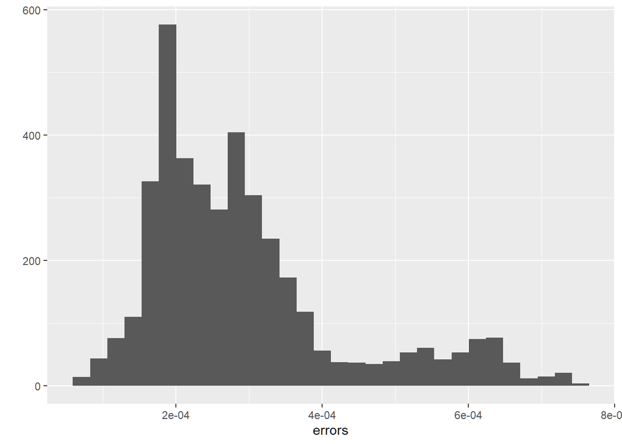

```r
qplot(errors, geom = "histogram")
```

### 3.3.3 Computing importance weights

With the reference model in place, it is time to compute the importance weights $\frac{p_{high}}{p_{low}}$ for each post-warmup draw. This is simple: just compute the log density of the reference model and the log density of the low precision model and take the difference (we work with the log of the importance ratios $\log p_{high} - \log p_{low}$ for numeric stability).

The hidden downside is that it might take some time to compute the log densities of the reference model for each draw. It should still be way faster than sampling with the reference model itself, since we don’t need to compute gradients, HMC trajectories, evaluate proposals that can be rejected, and skip the whole warmup period. Therefore we likely won’t have to try to do accurate ODE solves in the ill-behaved parameter regions, where a huge number of steps would be needed to achieve the ODE tolerances. Another upside is that the calculations can be done in parallel for each draw.

If the priors are kept the same between the reference and low precision model, then those can be left out of this calculation (they will cancel).

```r
log_lh_low = rep(0, num_draws)
log_lh_high = rep(0, num_draws)
for (i in seq_len(num_draws)) {
  y_hat_low = solve_sir(theta_draws[i,], rtol_low, atol_low,
                        max_num_steps_low)
  y_hat_high = solve_sir(theta_draws[i,], rtol_high, atol_high,
                         max_num_steps_high)
  log_lh_low[i] = sum(dnbinom(y, size = phi_draws[i],
                              mu = y_hat_low, log = TRUE))
  log_lh_high[i] = sum(dnbinom(y, size = phi_draws[i],
                              mu = y_hat_high, log = TRUE))
}
log_weights = log_lh_high - log_lh_low
```

We can plot the log importance ratios and see they are all close to zero (which means out approximation was not too bad).

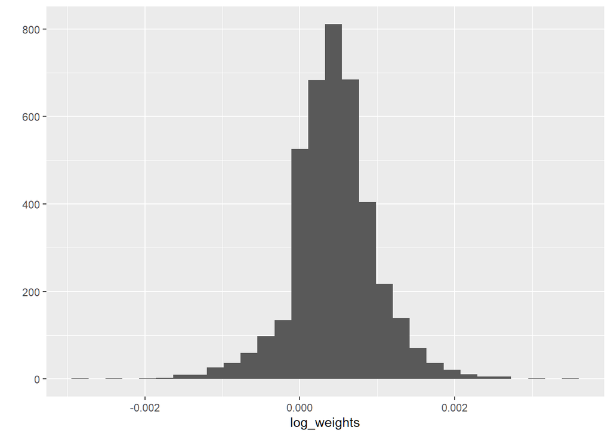

```r
qplot(log_weights, geom = "histogram")
```

### 3.3.4 Computing $\hat{k}$ diagnostic

With the importance ratios calculated, we can check if they are usable or not with the PSIS $\hat{k}$ diagnostic.

```r
loo::psis(log_weights)
```

```
## Computed from 4000 by 1 log-weights matrix
##
## All Pareto k estimates are good (k < 0.5).
## See help('pareto-k-diagnostic') for details.
```

$\hat{k} < 0.5$, and so importance sampling should be reliable.

### 3.3.5 Resampling

At this point we have a weighted set of posterior draws. It is usually easier to work with a set of draws than a set of weighted draws, so we can resample our weighted draws to become a set of unweighted draws using `posterior::resample_draws`. The effective sample size will be slightly lowered by such a resampling, but unweighted draws are really more convenient to work with.

Just because it is possible to do an importance sampling correction on a set of draws does not mean that unweighted statistics on these draws are safe to use. In this case, the results are not much different, but it should not be forgotten:

```r
w = exp(log_weights)
draws_list = rstan::extract(fit, c("beta", "gamma", "phi"))
draws_df = posterior::as_draws_df(draws_list)
resampled_df = posterior::resample_draws(draws_df,
                                         weights = w)

print(draws_df %>% posterior::summarize_draws())
```

```
## # A tibble: 3 x 10
##   variable  mean median     sd    mad    q5   q95  rhat ess_bulk ess_tail
##   <chr>    <dbl>  <dbl>  <dbl>  <dbl> <dbl> <dbl> <dbl>    <dbl>    <dbl>
## 1 beta     1.06   1.04  0.136  0.0994 0.898 1.28   1.00    3943.    4032.
## 2 gamma    0.201  0.201 0.0271 0.0260 0.157 0.247  1.00    3706.    3225.
## 3 phi      4.45   4.18  1.62   1.57   2.26  7.50   1.00    3978.    3713.
```

```r
print(resampled_df %>% posterior::summarize_draws())
```

```
## # A tibble: 3 x 10
##   variable  mean median     sd    mad    q5   q95  rhat ess_bulk ess_tail
##   <chr>    <dbl>  <dbl>  <dbl>  <dbl> <dbl> <dbl> <dbl>    <dbl>    <dbl>
## 1 beta     1.06   1.04  0.136  0.0999 0.896 1.28   1.00    3825.    3881.
## 2 gamma    0.201  0.201 0.0272 0.0260 0.157 0.247  1.00    3628.    3198.
## 3 phi      4.45   4.18  1.62   1.57   2.26  7.48   1.00    3876.    3642.
```

# 4 Heat Equation Example (PDE)

In this example we consider the diffusion of heat ($u(t, x)$) in a rod ($x \in [0, L]$).

For the purposes of this case study, the goal is to use a PDE solver in a model that has no automatic error control, only fixed discretization controls. This problem comes up from time to time when problems demand a custom solver be written – it is not always easy to tack on error control algorithms.

In this hypothetical experiment, the rod is cooled to room temperature and then heated from the left side. After some time the temperature profile of the rod is measured and from this the thermal diffusivity $K$ will be estimated.

The dynamics are governed by the 1D heat equation:

$$\begin{align}
\frac{\partial u}{\partial t} &= K \cdot \frac{\partial^2 u}{\partial x^2} \\
u(0, x) &= 0 \\
u(t, 0) &= 1 \\
u(t, L) &= 0
\end{align}$$

## 4.1 Solving the system

All of the computations in this example are going to be done with a method of lines discretization of this problem and a backwards Euler integrator. The appropriate math is described in the online lecture notes [ATM 623: Climate Modeling](http://www.atmos.albany.edu/facstaff/brose/classes/ATM623_Spring2015/Notes/Lectures/Lecture16%20--%20Numerical%20methods%20for%20diffusion%20models.html) by Brian E. J. Rose, though any introductory PDE reference should suffice.

For convenience we have defined a Stan function that solves equations above and computes the measured temperatures in the system given a timestep, a spatial discretization, a hypothetical diffusivity, a measurement time, and a list of measurement points.

```r
model = stan_model("stan/diffusion.stan")
expose_stan_functions(model)
```

```r
dt = 1.0
Nx = 10
K = 1e-1
T_meas = 0.1
x_meas = c(-1.0, 0.01, 0.5, 0.99, 1.0, 2.0)

solve_pde(dt, Nx, K, T_meas, x_meas)
```

```
## [1] 1.0000000000 0.8982480469 0.0200404568 0.0002739004 0.0000000000
## [6] 0.0000000000
```

The function has the signature:

```
vector solve_pde(dt, Nx, K, T_meas, x_meas)
```

with arguments:

- `dt` - Timestep
- `Nx` - Number of interior points in spatial discretization
- `K` - Thermal diffusivity
- `T_meas` - Measurement time
- `x_meas` - Measurement points

First, let’s set up constants and plot a possible solution with measurement points:

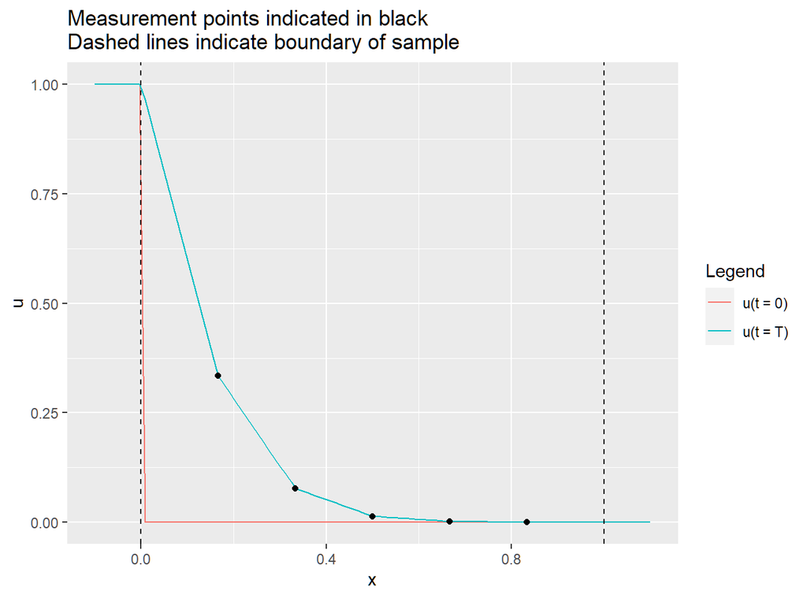

```r
dt = 1e-1
Nx = 5
L = 1.0

x_meas = seq(0.0, L, length = 7)[2:6]
T_meas = 1.0
K_true = 0.015

# For these calculations pretend we are measuring everywhere so we can
#  see the whole solution
x = seq(-0.1, 1.1, length = 100)
u0 = c(rep(1.0, sum(x <= 0.0)), rep(0.0, sum(x > 0.0)))
uT = solve_pde(dt, Nx, K_true, T_meas, x)

# Solve at only the measurement points
mu = solve_pde(dt, Nx, K_true, T_meas, x_meas)

# Plot
tibble(x = x, `u(t = 0)` = u0, `u(t = T)` = uT) %>%
  gather(Legend, u, -x) %>%
  ggplot(aes(x, u)) +
  geom_line(aes(color = Legend, group = Legend)) +
  geom_point(data = tibble(x = x_meas, u = mu)) +
  ggtitle("Measurement points indicated in black\nDashed lines indicate boundary of sample") +
  geom_vline(aes(xintercept = 0.0), linetype = "dashed") +
  geom_vline(aes(xintercept = L), linetype = "dashed")
```

The red line shows the initial conditions. Because the solution is actually discretized, to only five points on the rod (seven including the boundaries) we do linear interpolation to get the values in the intermediate points (which makes the boundary look a bit strange).

The teal points show the distribution of heat in the rod at time `t = T`, where we plan to take measurements (indicated by the black dots) and make an inference about the unknown thermal diffusivity of the rod.

## 4.2 Generating test data

Now that we can compute solutions to this problem, our first question will be is a given solution accurate enough? The simple way to check this is by computing the solution again at a higher space/time resolution and checking the difference.

We can define a convenience function that for a given discretization and experimental configuration computes a solution and also another solution at higher precision and returns the maximum absolute error.

```r
# Function to help determine if dt and Nx are small enough at given K
check_reliability = function(dt, Nx, K, T_meas, x_meas) {
  mu = solve_pde(dt, Nx, K, T_meas, x_meas)
  mu_more_accurate = solve_pde(dt / 2.0, 2 * Nx, K, T_meas, x_meas)
  max_abs_err = max(abs(mu_more_accurate - mu))
  return(max_abs_err)
}

# Check at K = K_true
check_reliability(dt, Nx, K_true, T_meas, x_meas)
```

```
## [1] 0.007415297
```

Is that error good or is that bad? That is something that will need to be determined in the context of the application. In this case we are going assume a measurement noise of $0.1$, and so we should get our numerical error quite a bit below that.

```r
dt = 0.01
Nx = 40
check_reliability(dt, Nx, K_true, T_meas, x_meas)
```

```
## [1] 0.001039788
```

This seems good enough for now, but you might further refine your solution. Now to simulate data:

```r
sigma = 0.1
noise = rnorm(length(x_meas), 0, sigma)
y = solve_pde(dt, Nx, K_true, T_meas, x_meas) + noise
```

## 4.3 Applying the workflow

### 4.3.1 Generating draws from $p_{low}$

Now that we have simulated data, it is time to do inference. The first step, similarly as for the ODE, is to fit an initial approximate model to our data. Again, all our calculations are approximations, and so we refer to this model as a low precision model because we will check it against a higher precision model later.

Assume we are very impatient and want this computation to finish quickly so that we use only one timestep and one spatial point of resolution in our discretization:

```r
dt_low = 1.0
Nx_low = 1
fit = rstan::sampling(model,
                data = list(dt = dt_low,
                            Nx = Nx_low,
                            N_meas = length(x_meas),
                            T_meas = T_meas,
                            x_meas = x_meas,
                            y = y),
                control = list(adapt_delta = 0.95),
                cores = 1)
```

Let us look at our results:

```r
print(fit, pars = c("K", "sigma"))
```

```
## Inference for Stan model: diffusion.
## 4 chains, each with iter=2000; warmup=1000; thin=1;
## post-warmup draws per chain=1000, total post-warmup draws=4000.
##
##       mean se_mean   sd 2.5%  25%  50%  75% 97.5% n_eff Rhat
## K     0.37    0.02 0.52 0.00 0.02 0.12 0.52  1.85  1154    1
## sigma 0.40    0.01 0.20 0.15 0.25 0.36 0.49  0.92   841    1
##
## Samples were drawn using NUTS(diag_e) at Mon Oct 26 17:27:15 2020.
## For each parameter, n_eff is a crude measure of effective sample size,
## and Rhat is the potential scale reduction factor on split chains (at
## convergence, Rhat=1).
```

### 4.3.2 Developing a reference model

Again, to check if the importance sampling correction can be done, we need a reference model that works for all the posterior draws we got from the low precision model. We can develop the reference model using the same technique we did previously (guess a high precision, and check the maximum absolute error between that high precision model and one of even higher precision).

```r
dt_high = 0.01
Nx_high = 100

K_draws = rstan::extract(fit, "K")$K
sigma_draws = rstan::extract(fit, "sigma")$sigma
num_draws = length(K_draws)

# Compute differences
errors = c()
for (i in 1:num_draws) {
  mae = check_reliability(dt_high, Nx_high, K_draws[i], T_meas, x_meas)
  errors = c(errors, mae)
}
```

With a simple one parameter model we can plot our approximate errors as a function of K (so we know the solution is suitable everywhere).

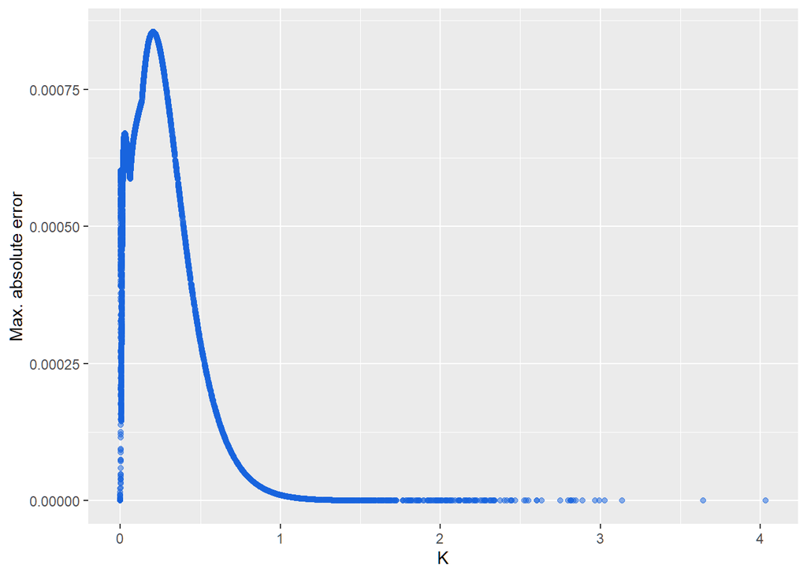

```r
error_plot = function(K, mae) {
  ylab =
  df = data.frame(K, mae)
  ggplot(df, aes_string(x = "K", y = "mae")) +
    geom_point(col = "#1864de", alpha = 0.5) +
    xlab("K") + ylab("Max. absolute error")
}
error_plot(K_draws, errors)
```

The errors here seem low enough.

### 4.3.3 Computing importance weights

The importance weights $\frac{p_{high}}{p_{low}}$ are computed on the log scale. The priors cancel out so we only need to work with log likelihoods.

Again, this step looks simple in this example, but in practice it might be more complicated. It is possible that the reference calculation is done with an entirely different piece of software. For instance, with a PDE perhaps a the reference solution is computed with a well-tested FEM solver in a different software environment entirely.

```r
# Define a function
compute_log_weights = function(
  dt_low, Nx_low, dt_high, Nx_high,
  K_draws, T_meas, x_meas, y_meas)
{
  log_lh_low = rep(0, num_draws)
  log_lh_high = rep(0, num_draws)
  for (i in seq_len(num_draws)) {
    mu_low = solve_pde(dt_low, Nx_low, K_draws[i], T_meas, x_meas)
    mu_high = solve_pde(dt_high, Nx_high, K_draws[i], T_meas, x_meas)
    log_lh_low[i] = sum(dnorm(y_meas, mu_low, sigma_draws[i], log = TRUE))
    log_lh_high[i] = sum(dnorm(y_meas, mu_high, sigma_draws[i], log = TRUE))
  }
  log_weights = log_lh_high - log_lh_low
  return(log_weights)
}

# Apply function
log_weights = compute_log_weights(dt_low, Nx_low, dt_high, Nx_high,
                                  K_draws, T_meas, x_meas, y)
```

### 4.3.4 Computing $\hat{k}$ diagnostic

If the $\hat{k}$ diagnostic is not low enough, it is not possible to do the importance sampling correction and we need to recompute our posterior with a higher resolution model. The `loo` package computes the $\hat{k}$ diagnostic for us:

```r
loo::psis(log_weights)
```

```
## Computed from 4000 by 1 log-weights matrix
## Pareto k diagnostic values:
##                          Count Pct.    Min. n_eff
## (-Inf, 0.5]   (good)     0       0.0%  <NA>
##  (0.5, 0.7]   (ok)       1     100.0%  196
##    (0.7, 1]   (bad)      0       0.0%  <NA>
##    (1, Inf)   (very bad) 0       0.0%  <NA>
##
## All Pareto k estimates are ok (k < 0.7).
## See help('pareto-k-diagnostic') for details.
```

Oh no! $\hat{k} > 0.5$, and it turns out modeling this process with one timestep and one spatial point was not a good idea. This means we need to up the precision in the low resolution model and go back to *Step 1*.

### 4.3.5 Repeating the loop

```r
dt_low = 0.1
Nx_low = 10
fit = rstan::sampling(model,
                data = list(dt = dt_low,
                            Nx = Nx_low,
                            N_meas = length(x_meas),
                            T_meas = T_meas,
                            x_meas = x_meas,
                            y = y),
                control = list(adapt_delta = 0.95),
                cores = 1)
```

Again, we can check our regular diagnostics:

```r
print(fit, pars = c("K", "sigma"))
```

```
## Inference for Stan model: diffusion.
## 4 chains, each with iter=2000; warmup=1000; thin=1;
## post-warmup draws per chain=1000, total post-warmup draws=4000.
##
##       mean se_mean   sd 2.5%  25%  50%  75% 97.5% n_eff Rhat
## K     0.09    0.01 0.27 0.01 0.02 0.03 0.04  0.99   404 1.00
## sigma 0.21    0.01 0.15 0.08 0.12 0.17 0.24  0.66   453 1.01
##
## Samples were drawn using NUTS(diag_e) at Mon Oct 26 17:27:24 2020.
## For each parameter, n_eff is a crude measure of effective sample size,
## and Rhat is the potential scale reduction factor on split chains (at
## convergence, Rhat=1).
```

Again, we verify our reference solution:

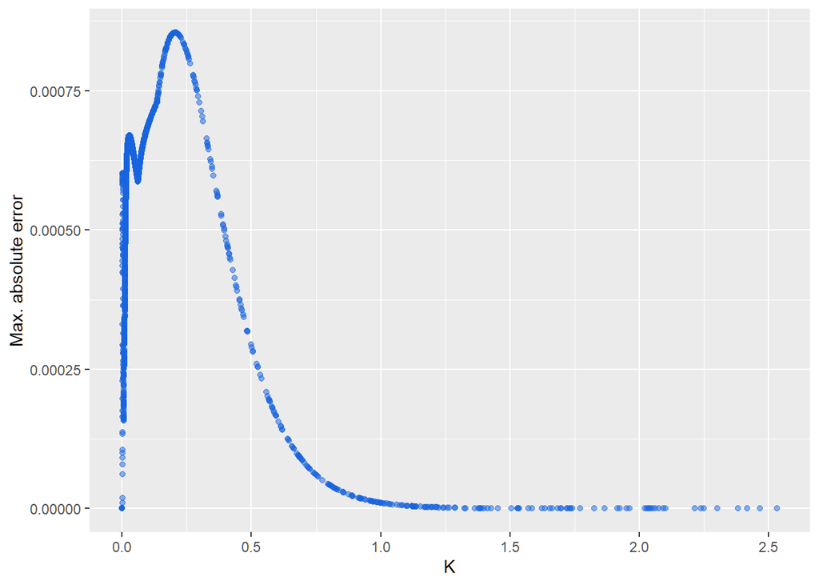

```r
K_draws = rstan::extract(fit, "K")$K
sigma_draws = rstan::extract(fit, "sigma")$sigma
num_draws = length(K_draws)

# Compute differences
errors = c()
for (i in 1:num_draws) {
  mae = check_reliability(dt_high, Nx_high, K_draws[i], T_meas, x_meas)
  errors = c(errors, mae)
}

# Plot
error_plot(K_draws, errors)
```

And again we can compute the importance ratios and run the PSIS diagnostics on them:

```r
log_weights = compute_log_weights(dt_low, Nx_low, dt_high, Nx_high,
                                  K_draws, T_meas, x_meas, y)
loo::psis(log_weights)
```

```
## Computed from 4000 by 1 log-weights matrix
##
## All Pareto k estimates are good (k < 0.5).
## See help('pareto-k-diagnostic') for details.
```

And this time $\hat{k} < 0.5$, so we are good enough!

### 4.3.6 Resampling draws

At this point we have a weighted set of posterior draws. Again it is usually easier to work with a set of draws than a set of weighted draws, so we resample our weighted draws using `posterior::resample_draws`.

```r
w = exp(log_weights)
draws_list = rstan::extract(fit, c("K", "sigma"))
draws_df = posterior::as_draws_df(draws_list)
resampled_df = posterior::resample_draws(draws_df,
                                         weights = w)

print(draws_df %>% posterior::summarize_draws())
```

```
## # A tibble: 2 x 10
##   variable   mean median    sd    mad      q5   q95  rhat ess_bulk ess_tail
##   <chr>     <dbl>  <dbl> <dbl>  <dbl>   <dbl> <dbl> <dbl>    <dbl>    <dbl>
## 1 K        0.0922 0.0257 0.265 0.0144 0.00921 0.485  1.00    3889.    3947.
## 2 sigma    0.211  0.165  0.147 0.0762 0.0868  0.524  1.00    3981.    3760.
```

```r
print(resampled_df %>% posterior::summarize_draws())
```

```
## # A tibble: 2 x 10
##   variable   mean median    sd    mad     q5   q95  rhat ess_bulk ess_tail
##   <chr>     <dbl>  <dbl> <dbl>  <dbl>  <dbl> <dbl> <dbl>    <dbl>    <dbl>
## 1 K        0.0929 0.0259 0.271 0.0136 0.0104 0.483  1.00    2658.    2798.
## 2 sigma    0.209  0.162  0.144 0.0751 0.0854 0.511  1.00    2966.    2577.
```

# 5 Conclusions

And that is that! Happy approximating!

# References

Grinsztajn, Léo, Elizaveta Semenova, Charles C. Margossian, and Julien Riou. 2020. “Bayesian Workflow for Disease Transmission Modeling in Stan.” https://mc-stan.org/users/documentation/case-studies/boarding_school_case_study.html.

Vehtari, Aki, Daniel Simpson, Andrew Gelman, Yuling Yao, and Jonah Gabry. 2019. “Pareto Smoothed Importance Sampling.” http://arxiv.org/abs/1507.02646.

Yao, Yuling, Aki Vehtari, Daniel Simpson, and Andrew Gelman. 2018. “Yes, but Did It Work?: Evaluating Variational Inference.” http://arxiv.org/abs/1802.02538.